# Regression Model for [Project Name] Using R version 11

## 4. Model and Evaluate Algorithms

After the data-prep, we next work on finding a workable model by evaluating a subset of machine learning algorithms that are good at exploiting the structure of the dataset. The typical evaluation tasks include:

- Defining test options such as cross validation and the evaluation metric to use.
- Spot checking a suite of linear and nonlinear machine learning algorithms.
- Comparing the estimated accuracy of algorithms.

For this project, we will evaluate four linear, one non-linear, and three ensemble algorithms:

Linear Algorithms: Linear Regression, Ridge, The Lasso, Elasticnet

Non-Linear Algorithm: Decision Trees (CART)

Ensemble Algorithms: Bagged CART, Random Forest, and Gradient Boosting

The random number seed is reset before each run to ensure that the evaluation of each algorithm is performed using the same data splits. It ensures the results are directly comparable.

### 4.a) Generate models using linear algorithms

```r
# Linear Regression (Regression)
if (notifyStatus) email_notify(paste("Linear Regression modeling has begun!",date()))
startTimeModule <- proc.time()
set.seed(seedNum)
fit.lm <- train(targetVar~., data=Xy_train, method="lm", metric=metricTarget, trControl=control)
print(fit.lm)
```

```
## Linear Regression
##
## 381 samples
##  13 predictor
##
## No pre-processing
## Resampling: Cross-Validated (10 fold, repeated 1 times)
## Summary of sample sizes: 343, 344, 343, 344, 342, 343, ...
## Resampling results:
##
##   RMSE      Rsquared   MAE
##   4.581715  0.7630488  3.327011
##
## Tuning parameter 'intercept' was held constant at a value of TRUE
```

```r
proc.time()-startTimeModule
```

```
##    user  system elapsed
##   0.698   0.000   0.700
```

```r
if (notifyStatus) email_notify(paste("Linear Regression modeling completed!",date()))
```

```r
# Ridge (Regression)
if (notifyStatus) email_notify(paste("Ridge Regression modeling has begun!",date()))
startTimeModule <- proc.time()
set.seed(seedNum)
fit.ridge <- train(targetVar~., data=Xy_train, method="ridge", metric=metricTarget, trControl=control)
print(fit.ridge)
```

```
## Ridge Regression
##
## 381 samples
##  13 predictor
##
## No pre-processing
## Resampling: Cross-Validated (10 fold, repeated 1 times)
## Summary of sample sizes: 343, 344, 343, 344, 342, 343, ...
## Resampling results across tuning parameters:
##
##   lambda  RMSE      Rsquared   MAE
##   0e+00   4.581715  0.7630488  3.327011
##   1e-04   4.581624  0.7630543  3.326831
##   1e-01   4.591321  0.7617713  3.286007
##
## RMSE was used to select the optimal model using the smallest value.
## The final value used for the model was lambda = 1e-04.
```

```r
proc.time()-startTimeModule
```

```
##    user  system elapsed
##   0.801   0.000   0.802
```

```r
if (notifyStatus) email_notify(paste("Ridge Regression modeling completed!",date()))
```

```r
# The Lasso (Regression)
if (notifyStatus) email_notify(paste("The Lasso modeling has begun!",date()))
startTimeModule <- proc.time()
set.seed(seedNum)
fit.lasso <- train(targetVar~., data=Xy_train, method="lasso", metric=metricTarget, trControl=control)
print(fit.lasso)
```

```
## The lasso
##
## 381 samples
##  13 predictor
##
## No pre-processing
## Resampling: Cross-Validated (10 fold, repeated 1 times)
## Summary of sample sizes: 343, 344, 343, 344, 342, 343, ...
## Resampling results across tuning parameters:
##
##   fraction  RMSE      Rsquared   MAE
##   0.1       7.714433  0.6510875  5.480781
##   0.5       4.840859  0.7350125  3.395638
##   0.9       4.578090  0.7625927  3.281449
##
## RMSE was used to select the optimal model using the smallest value.
## The final value used for the model was fraction = 0.9.
```

```r
proc.time()-startTimeModule
```

```
##    user  system elapsed
##   0.668   0.000   0.669
```

```r
if (notifyStatus) email_notify(paste("The Lasso modeling completed!",date()))
```

```r
# Elasticnet (Regression)
if (notifyStatus) email_notify(paste("Elasticnet modeling has begun!",date()))
startTimeModule <- proc.time()
set.seed(seedNum)
fit.enet <- train(targetVar~., data=Xy_train, method="enet", metric=metricTarget, trControl=control)
print(fit.enet)
```

```
## Elasticnet
##
## 381 samples
##  13 predictor
##
## No pre-processing
## Resampling: Cross-Validated (10 fold, repeated 1 times)
## Summary of sample sizes: 343, 344, 343, 344, 342, 343, ...
## Resampling results across tuning parameters:
##
##   lambda  fraction  RMSE      Rsquared   MAE
##   0e+00   0.050     8.441342  0.5984133  6.037670
##   0e+00   0.525     4.798398  0.7392440  3.364086
##   0e+00   1.000     4.581715  0.7630488  3.327011
##   1e-04   0.050     8.441618  0.5983861  6.037887
##   1e-04   0.525     4.798689  0.7392108  3.364345
##   1e-04   1.000     4.581624  0.7630543  3.326831
##   1e-01   0.050     8.539082  0.5964890  6.114630
##   1e-01   0.525     4.893107  0.7267467  3.464349
##   1e-01   1.000     4.591321  0.7617713  3.286007
##
## RMSE was used to select the optimal model using the smallest value.
## The final values used for the model were fraction = 1 and lambda = 1e-04.
```

```r
proc.time()-startTimeModule
```

```
##    user  system elapsed
##   0.895   0.000   0.896
```

```r
if (notifyStatus) email_notify(paste("Elasticnet modeling completed!",date()))
```

### 4.b) Generate models using nonlinear algorithms

```r
# Decision Tree - CART (Regression/Classification)
if (notifyStatus) email_notify(paste("Decision Tree modeling has begun!",date()))
startTimeModule <- proc.time()
set.seed(seedNum)
fit.cart <- train(targetVar~., data=Xy_train, method="rpart", metric=metricTarget, trControl=control)
print(fit.cart)
```

```
## CART
##
## 381 samples
##  13 predictor
##
## No pre-processing
## Resampling: Cross-Validated (10 fold, repeated 1 times)
## Summary of sample sizes: 343, 344, 343, 344, 342, 343, ...
## Resampling results across tuning parameters:
##
##   cp          RMSE      Rsquared   MAE
##   0.07710621  5.302389  0.6725038  3.763598
##   0.15682486  6.374733  0.5012787  4.708989
##   0.49602302  8.063640  0.3700832  5.820284
##
## RMSE was used to select the optimal model using the smallest value.
## The final value used for the model was cp = 0.07710621.
```

```r
proc.time()-startTimeModule
```

```
##    user  system elapsed
##   0.772   0.000   0.775
```

```r
if (notifyStatus) email_notify(paste("Decision Tree modeling completed!",date()))
```

### 4.c) Generate models using ensemble algorithms

In this section, we will explore the use and tuning of ensemble algorithms to see whether we can improve the results.

```r
# Bagged CART (Regression/Classification)
if (notifyStatus) email_notify(paste("Bagged CART modeling has begun!",date()))
startTimeModule <- proc.time()
set.seed(seedNum)
fit.bagcart <- train(targetVar~., data=Xy_train, method="treebag", metric=metricTarget, trControl=control)
print(fit.bagcart)
```

```
## Bagged CART
##
## 381 samples
##  13 predictor
##
## No pre-processing
## Resampling: Cross-Validated (10 fold, repeated 1 times)
## Summary of sample sizes: 343, 344, 343, 344, 342, 343, ...
## Resampling results:
##
##   RMSE      Rsquared   MAE
##   3.801649  0.8331995  2.681598
```

```r
proc.time()-startTimeModule
```

```
##    user  system elapsed
##   2.132   0.000   2.135
```

```r
if (notifyStatus) email_notify(paste("Bagged CART modeling completed!",date()))
```

```r
# Random Forest (Regression/Classification)
if (notifyStatus) email_notify(paste("Random Forest modeling has begun!",date()))
startTimeModule <- proc.time()
set.seed(seedNum)
fit.rf <- train(targetVar~., data=Xy_train, method="rf", metric=metricTarget, trControl=control)
print(fit.rf)
```

```
## Random Forest
##
## 381 samples
##  13 predictor
##
## No pre-processing
## Resampling: Cross-Validated (10 fold, repeated 1 times)
## Summary of sample sizes: 343, 344, 343, 344, 342, 343, ...
## Resampling results across tuning parameters:
##
##   mtry  RMSE      Rsquared   MAE
##    2    3.408869  0.8808420  2.392759
##    7    3.097099  0.8916944  2.195982
##   13    3.352567  0.8692344  2.292407
##
## RMSE was used to select the optimal model using the smallest value.
## The final value used for the model was mtry = 7.
```

```r
proc.time()-startTimeModule
```

```
##    user  system elapsed
##  19.393   0.000  19.435
```

```r
if (notifyStatus) email_notify(paste("Random Forest modeling completed!",date()))
```

```r
# Gradient Boosting (Regression/Classification)
if (notifyStatus) email_notify(paste("Gradient Boosting modeling has begun!",date()))
startTimeModule <- proc.time()
set.seed(seedNum)
fit.gbm <- train(targetVar~., data=Xy_train, method="xgbTree", metric=metricTarget, trControl=control, verbose=F)
# fit.gbm <- train(targetVar~., data=Xy_train, method="gbm", metric=metricTarget, trControl=control, verbose=F)
print(fit.gbm)
```

```
## eXtreme Gradient Boosting
##
## 381 samples
##  13 predictor
##
## No pre-processing
## Resampling: Cross-Validated (10 fold, repeated 1 times)
## Summary of sample sizes: 343, 344, 343, 344, 342, 343, ...
## Resampling results across tuning parameters:
##
##   eta  max_depth  colsample_bytree  subsample  nrounds  RMSE
##   0.3  1          0.6               0.50        50      3.627396
##   0.3  1          0.6               0.50       100      3.614612
##   0.3  1          0.6               0.50       150      3.641456
##   0.3  1          0.6               0.75        50      3.661027
##   0.3  1          0.6               0.75       100      3.596968
##   0.3  1          0.6               0.75       150      3.577292
##   0.3  1          0.6               1.00        50      3.618352
##   0.3  1          0.6               1.00       100      3.615412
##   0.3  1          0.6               1.00       150      3.633481
##   0.3  1          0.8               0.50        50      3.740155
##   0.3  1          0.8               0.50       100      3.739617
##   0.3  1          0.8               0.50       150      3.701426
##   0.3  1          0.8               0.75        50      3.692938
##   0.3  1          0.8               0.75       100      3.697656
##   0.3  1          0.8               0.75       150      3.734177
##   0.3  1          0.8               1.00        50      3.557645
##   0.3  1          0.8               1.00       100      3.575515
##   0.3  1          0.8               1.00       150      3.605403
##   0.3  2          0.6               0.50        50      3.281769
##   0.3  2          0.6               0.50       100      3.257692
##   0.3  2          0.6               0.50       150      3.280985
##   0.3  2          0.6               0.75        50      3.336774
##   0.3  2          0.6               0.75       100      3.300380
##   0.3  2          0.6               0.75       150      3.288701
##   0.3  2          0.6               1.00        50      3.320127
##   0.3  2          0.6               1.00       100      3.338395
##   0.3  2          0.6               1.00       150      3.342514
##   0.3  2          0.8               0.50        50      3.329962
##   0.3  2          0.8               0.50       100      3.303309
```

[output cut: 181 more lines]

```
##   0.8502711  2.571045
##   0.8845985  2.293583
##   0.8819988  2.341445
##   0.8827257  2.338500
##   0.8903641  2.339621
##   0.8867427  2.382228
##   0.8857230  2.395980
##
## Tuning parameter 'gamma' was held constant at a value of 0
##
## Tuning parameter 'min_child_weight' was held constant at a value of 1
## RMSE was used to select the optimal model using the smallest value.
## The final values used for the model were nrounds = 50, max_depth = 3,
##  eta = 0.4, gamma = 0, colsample_bytree = 0.6, min_child_weight = 1
##  and subsample = 1.
```

```r
proc.time()-startTimeModule
```

```
##    user  system elapsed
##  37.215   2.844  21.067
```

```r
if (notifyStatus) email_notify(paste("Gradient Boosting modeling completed!",date()))
```

### 4.d) Compare baseline algorithms

```r
results <- resamples(list(LR=fit.lm, RIDGE=fit.ridge, LASSO=fit.lasso, ENET=fit.enet, CART=fit.cart, BagCART=fit.bagcart, RF=fit.rf, GBM=fit.gbm))
summary(results)
```

```
##
## Call:
## summary.resamples(object = results)
##
## Models: LR, RIDGE, LASSO, ENET, CART, BagCART, RF, GBM
## Number of resamples: 10
##
## MAE
##             Min.  1st Qu.   Median     Mean  3rd Qu.     Max. NA's
## LR      2.588214 2.923187 3.309820 3.327011 3.630840 4.162791    0
## RIDGE   2.588241 2.923053 3.309471 3.326831 3.630690 4.162874    0
## LASSO   2.578677 2.936891 3.247625 3.281449 3.522095 4.139520    0
## ENET    2.588241 2.923053 3.309471 3.326831 3.630690 4.162874    0
## CART    3.430796 3.492995 3.644404 3.763598 4.022973 4.311316    0
## BagCART 2.013018 2.456054 2.589235 2.681598 2.911392 3.693791    0
## RF      1.389153 1.839434 2.243006 2.195982 2.482668 3.122009    0
## GBM     1.717205 1.937253 2.128442 2.282791 2.334926 3.651760    0
##
## RMSE
##             Min.  1st Qu.   Median     Mean  3rd Qu.     Max. NA's
## LR      3.307508 3.877180 4.332355 4.581715 4.888829 6.561910    0
## RIDGE   3.307490 3.877095 4.332127 4.581624 4.888911 6.562244    0
## LASSO   3.278058 3.898160 4.365034 4.578090 4.827390 6.646744    0
## ENET    3.307490 3.877095 4.332127 4.581624 4.888911 6.562244    0
## CART    4.263012 4.706868 5.098324 5.302389 5.791789 6.960350    0
## BagCART 2.386881 3.455206 3.680151 3.801649 3.923202 5.754866    0
## RF      1.727568 2.584235 3.086950 3.097099 3.531924 4.492519    0
## GBM     2.152952 2.629336 2.935517 3.078365 3.392817 4.732853    0
##
## Rsquared
##              Min.   1st Qu.    Median      Mean   3rd Qu.      Max. NA's
## LR      0.5468198 0.7201938 0.7943648 0.7630488 0.8396305 0.8643916    0
## RIDGE   0.5467861 0.7202026 0.7944001 0.7630543 0.8396553 0.8644008    0
## LASSO   0.5351914 0.7226683 0.7980042 0.7625927 0.8429875 0.8636920    0
## ENET    0.5467861 0.7202026 0.7944001 0.7630543 0.8396553 0.8644008    0
## CART    0.4626498 0.6454842 0.7112850 0.6725038 0.7269716 0.7823333    0
## BagCART 0.6872423 0.8052091 0.8553612 0.8331995 0.8802376 0.9197336    0
## RF      0.8256543 0.8603605 0.8943873 0.8916944 0.9240301 0.9559660    0
## GBM     0.8124105 0.8720673 0.8965363 0.8916496 0.9244110 0.9351675    0
```

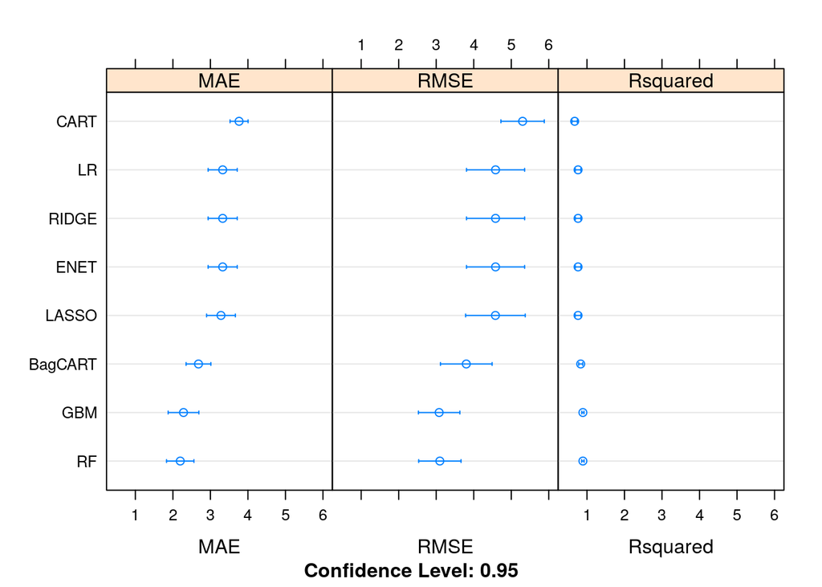

```r
dotplot(results)
```

```r
cat('The average RMSE from all models is:',
    mean(c(results$values$`LR~RMSE`,results$values$`RIDGE~RMSE`,results$values$`LASSO~RMSE`,results$values$`ENET~RMSE`,results$values$`CART~RMSE`,results$values$`BagCART~RMSE`,results$values$`RF~RMSE`,results$values$`GBM~RMSE`)))
```

```
## The average RMSE from all models is: 4.20032
```

## 5. Improve Accuracy or Results

After we achieve a short list of machine learning algorithms with good level of accuracy, we can leverage ways to improve the accuracy of the models.

### 5.a) Algorithm Tuning

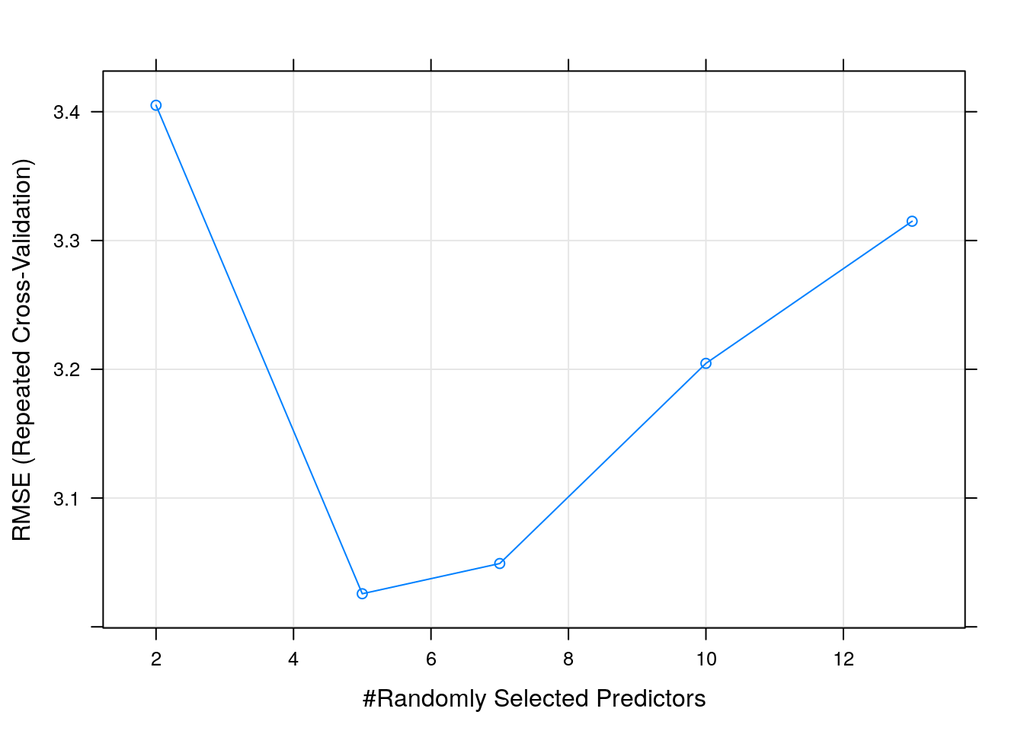

```r
# Tuning algorithm #1 - Random Forest
if (notifyStatus) email_notify(paste("Algorithm #1 tuning has begun!",date()))
startTimeModule <- proc.time()
set.seed(seedNum)
grid <- expand.grid(mtry = c(2,5,7,10,13))
fit.final1 <- train(targetVar~., data=Xy_train, method="rf", metric=metricTarget, tuneGrid=grid, trControl=control)
plot(fit.final1)
```

```r
print(fit.final1)
```

```
## Random Forest
##
## 381 samples
##  13 predictor
##
## No pre-processing
## Resampling: Cross-Validated (10 fold, repeated 1 times)
## Summary of sample sizes: 343, 344, 343, 344, 342, 343, ...
## Resampling results across tuning parameters:
##
##   mtry  RMSE      Rsquared   MAE
##    2    3.405013  0.8822832  2.382702
##    5    3.025698  0.8992843  2.177460
##    7    3.049176  0.8954097  2.185070
##   10    3.204597  0.8819619  2.241143
##   13    3.314961  0.8717789  2.283085
##
## RMSE was used to select the optimal model using the smallest value.
## The final value used for the model was mtry = 5.
```

```r
proc.time()-startTimeModule
```

```
##    user  system elapsed
##  31.459   0.063  31.593
```

```r
if (notifyStatus) email_notify(paste("Algorithm #1 tuning completed!",date()))
```

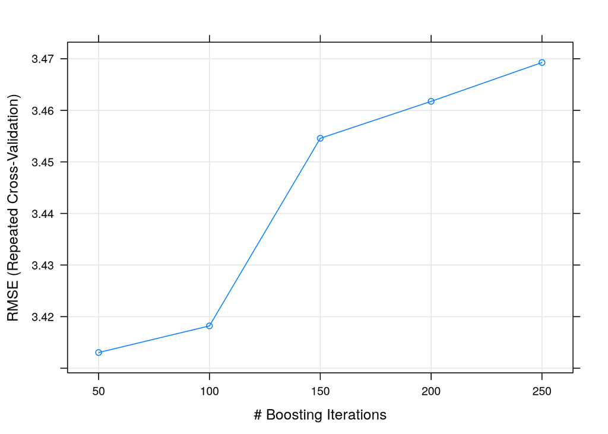

```r
# Tuning algorithm #2 - Gradient Boosting
if (notifyStatus) email_notify(paste("Algorithm #2 tuning has begun!",date()))
startTimeModule <- proc.time()
set.seed(seedNum)
grid <- expand.grid(nrounds=c(50,100,150,200,250), max_depth=3, eta=0.4, gamma=0, colsample_bytree=0.6, min_child_weight=1, subsample=1)
fit.final2 <- train(targetVar~., data=Xy_train, method="xgbTree", metric=metricTarget, tuneGrid=grid, trControl=control, verbose=F)
plot(fit.final2)
```

```r
print(fit.final2)
```

[output not shown]

```r
proc.time()-startTimeModule
```

```
##    user  system elapsed
##   2.603   0.167   1.775
```

```r
if (notifyStatus) email_notify(paste("Algorithm #2 tuning completed!",date()))
```

### 5.d) Compare Algorithms After Tuning

```r
results <- resamples(list(RF=fit.final1, GBM=fit.final2))
summary(results)
```

```
##
## Call:
## summary.resamples(object = results)
##
## Models: RF, GBM
## Number of resamples: 10
##
## MAE
##         Min.  1st Qu.   Median     Mean  3rd Qu.     Max. NA's
## RF  1.424899 1.824279 2.227058 2.177460 2.426850 2.945685    0
## GBM 2.014455 2.086014 2.391468 2.435746 2.609524 3.381662    0
##
## RMSE
##         Min.  1st Qu.   Median     Mean  3rd Qu.     Max. NA's
## RF  1.719622 2.485144 2.979666 3.025698 3.650008 4.338862    0
## GBM 2.446053 2.923803 3.229311 3.413043 3.830787 4.538194    0
##
## Rsquared
##          Min.   1st Qu.    Median      Mean   3rd Qu.      Max. NA's
## RF  0.8432210 0.8685587 0.8948657 0.8992843 0.9347146 0.9584887    0
## GBM 0.7892286 0.8501185 0.8768140 0.8682363 0.8963518 0.9095538    0
```

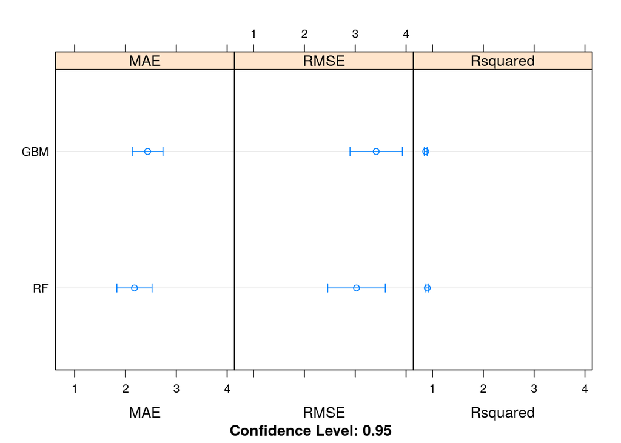

```r
dotplot(results)
```

## 6. Finalize Model and Present Results

Once we have narrow down to a model that we believe can make accurate predictions on unseen data, we are ready to finalize it. Finalizing a model may involve sub-tasks such as:

- Using an optimal model tuned to make predictions on unseen data.
- Creating a standalone model using the tuned parameters
- Saving an optimal model to file for later use.

```r
if (notifyStatus) email_notify(paste("Model Validation and Final Model Creation has begun!",date()))
```

### 6.a) Predictions on validation dataset

```r
predictions <- predict(fit.final1, newdata=Xy_test)
cat("The RMSE for the test data is:", RMSE(predictions, y_test))
```

```
## The RMSE for the test data is: 4.344504
```

```r
cat("The R2 score for the model is:", R2(predictions, y_test))
```

```
## The R2 score for the model is: 0.7788802
```

```r
predictions <- predict(fit.final2, newdata=Xy_test)
cat("The RMSE for the test data is:", RMSE(predictions, y_test))
```

```
## The RMSE for the test data is: 3.943575
```

```r
cat("The R2 score for the model is:", R2(predictions, y_test))
```

```
## The R2 score for the model is: 0.8174563
```

### 6.b) Create standalone model on entire training dataset

```r
startTimeModule <- proc.time()
set.seed(seedNum)
library(randomForest)
# Combining datasets to form a complete dataset that will be used to train the final model
Xy_complete <- rbind(Xy_train, Xy_test)

finalModel <- randomForest(targetVar~., Xy_complete, mtry=5, na.action=na.omit)
summary(finalModel)
```

```
##                 Length Class  Mode
## call              5    -none- call
## type              1    -none- character
## predicted       506    -none- numeric
## mse             500    -none- numeric
## rsq             500    -none- numeric
## oob.times       506    -none- numeric
## importance       13    -none- numeric
## importanceSD      0    -none- NULL
## localImportance   0    -none- NULL
## proximity         0    -none- NULL
## ntree             1    -none- numeric
## mtry              1    -none- numeric
## forest           11    -none- list
## coefs             0    -none- NULL
## y               506    -none- numeric
## test              0    -none- NULL
## inbag             0    -none- NULL
## terms             3    terms  call
```

```r
proc.time()-startTimeModule
```

```
##    user  system elapsed
##   0.756   0.004   0.761
```

### 6.c) Save model for later use

```r
#saveRDS(finalModel, "./finalModel_Regression.rds")
```

```r
if (notifyStatus) email_notify(paste("Model Validation and Final Model Creation Completed!",date()))
proc.time()-startTimeScript
```

```
##    user  system elapsed
## 106.455   3.376  89.975
```